# Assignment4_BDBM

So, first, let’s find the AUC using cancer dataset both as training and test, without splitting. Note: In in lecture notes, Manny calculated the AUC using same dataset for training and testing with max depth parameter= 2, and then compared the AUC to a model in which the test and training set are separated, amd maxdepth=2. If the AUC is similar under both conditions, there is no overfitting in the data. I have used a similar principle.

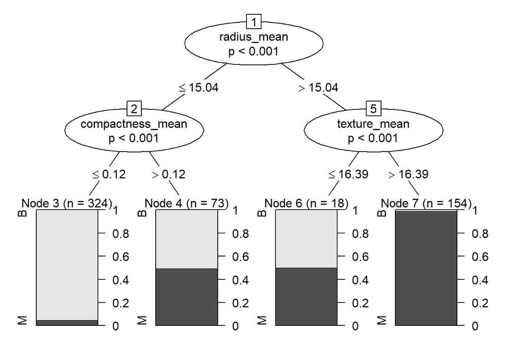

```r
Disease_Cancer<-ctree(formula= diagnosis~ radius_mean+texture_mean+smoothness_mean+ compactness_mean,data=cancer_data,  controls = ctree_control(maxdepth = 2))
plot(Disease_Cancer)
```

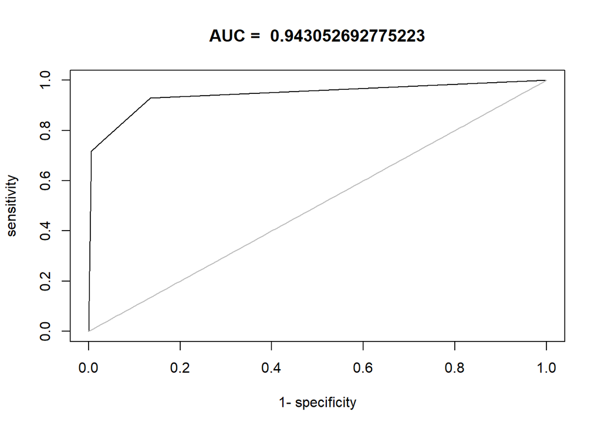

```r
resultsr = predict(Disease_Cancer,
                    type="response")
resultsp = predict(Disease_Cancer,
                    type="prob")
resultsp.df1 = t(as.data.frame(resultsp))
roc_result = roc(resultsp.df1[,2],cancer_data$diagnosis)
plot(roc_result, main=paste("AUC = ", auc(roc_result), sep=" "))
```

##When maxdepth =1

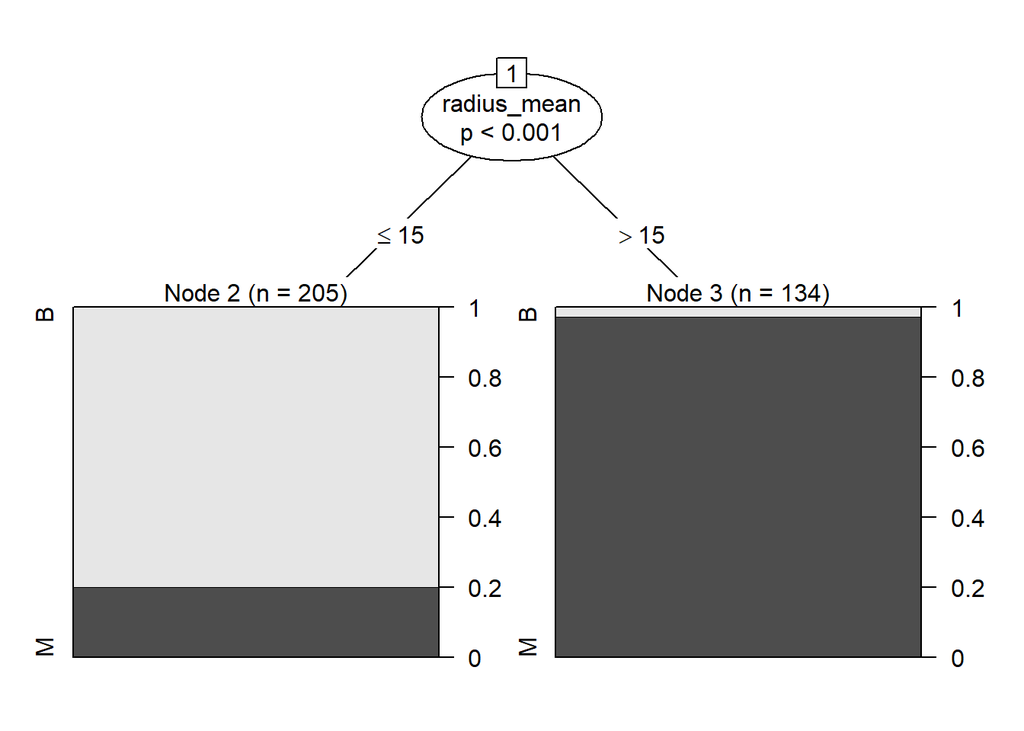

```r
Disease.fit1<-ctree(formula= diagnosis~ radius_mean+texture_mean+smoothness_mean+ compactness_mean,data=split.train1,
                   controls = ctree_control(maxdepth = 1))
plot(Disease.fit1)
```

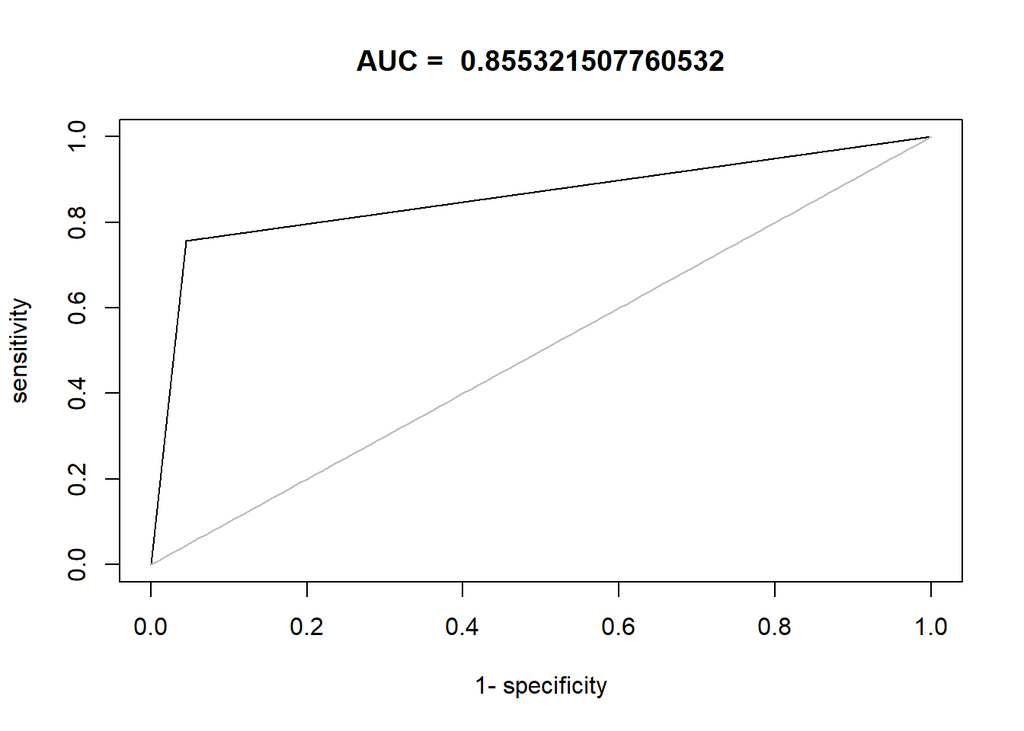

```r
results3r1 = predict(Disease.fit1,
                    newdata=split.test1,
                    type="response")
tree_confmat1<-table(split.test1[,"diagnosis"],results3r1,dnn=c("actual","predicted"))
results3p1 = predict(Disease.fit1, newdata=split.test1,
                    type="prob")
results3p.df1 = t(as.data.frame(results3p1))
roc_result31 = roc(results3p.df1[,2],split.test1$diagnosis)
plot(roc_result31, main=paste("AUC = ", auc(roc_result31), sep=" "))
```

```r
tree_confmat1
```

```
##       predicted
## actual  B  M
##      B 42  2
##      M 10 31
```

```r
TP_DT1=tree_confmat1["M","M"]
TN_DT1=tree_confmat1["B","B"]
FP_DT1=tree_confmat1["B","M"]
FN_DT1=tree_confmat1["M","B"]
accuracy1=(TP_DT1+TN_DT1)/sum(TP_DT1,TN_DT1,FP_DT1,FN_DT1)
accuracy1
```

```
## [1] 0.8588235
```

```r
precision1=TP_DT1/(TP_DT1+FP_DT1)
precision1
```

```
## [1] 0.9393939
```

```r
Recall_DT1=TP_DT1/(TP_DT1+FN_DT1)
Recall_DT1
```

```
## [1] 0.7560976
```

##When maxdepth =2

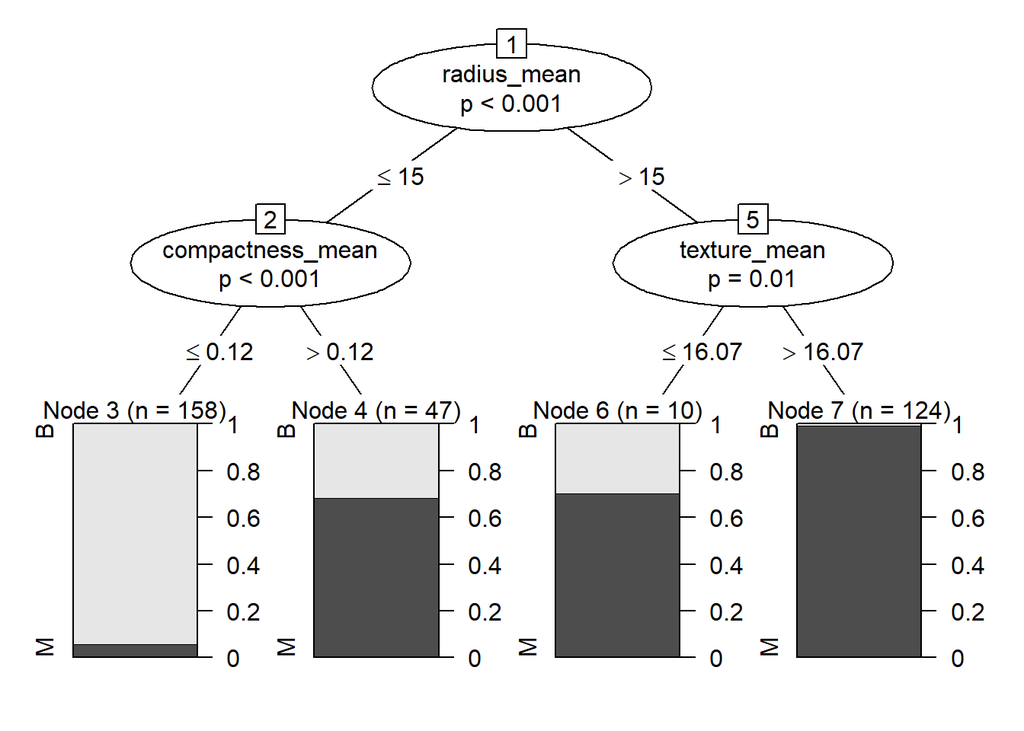

```r
Disease.fit2<-ctree(formula= diagnosis~ radius_mean+texture_mean+smoothness_mean+ compactness_mean,data=split.train1,
                   controls = ctree_control(maxdepth = 2))
plot(Disease.fit2)
```

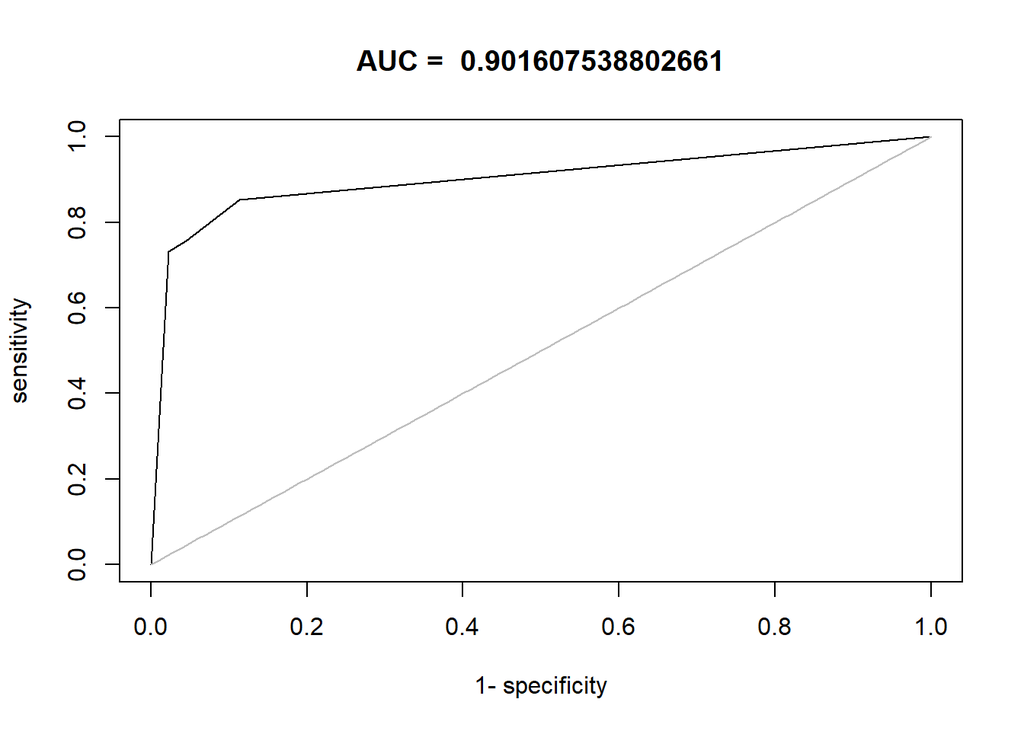

```r
results3r2 = predict(Disease.fit2,
                    newdata=split.test1,
                    type="response")
tree_confmat2<-table(split.test1[,"diagnosis"],results3r2,dnn=c("actual","predicted"))
results3p2 = predict(Disease.fit2, newdata=split.test1,
                    type="prob")
results3p.df2 = t(as.data.frame(results3p2))
roc_result32 = roc(results3p.df2[,2],split.test1$diagnosis)
plot(roc_result32, main=paste("AUC = ", auc(roc_result32), sep=" "))
```

## slightly better AUC when maxdepth=2

```r
tree_confmat2
```

```
##       predicted
## actual  B  M
##      B 39  5
##      M  6 35
```

```r
TP_DT2=tree_confmat2["M","M"]
TN_DT2=tree_confmat2["B","B"]
FP_DT2=tree_confmat2["B","M"]
FN_DT2=tree_confmat2["M","B"]
accuracy2=(TP_DT2+TN_DT2)/sum(TP_DT2,TN_DT2,FP_DT2,FN_DT2)
accuracy2
```

```
## [1] 0.8705882
```

```r
TN_DT2
```

```
## [1] 39
```

```r
precision2=TP_DT2/(TP_DT2+FP_DT2)
precision2
```

```
## [1] 0.875
```

```r
Recall_DT2=TP_DT2/(TP_DT2+FN_DT2)
Recall_DT2
```

```
## [1] 0.8536585
```

##When maxdepth =3

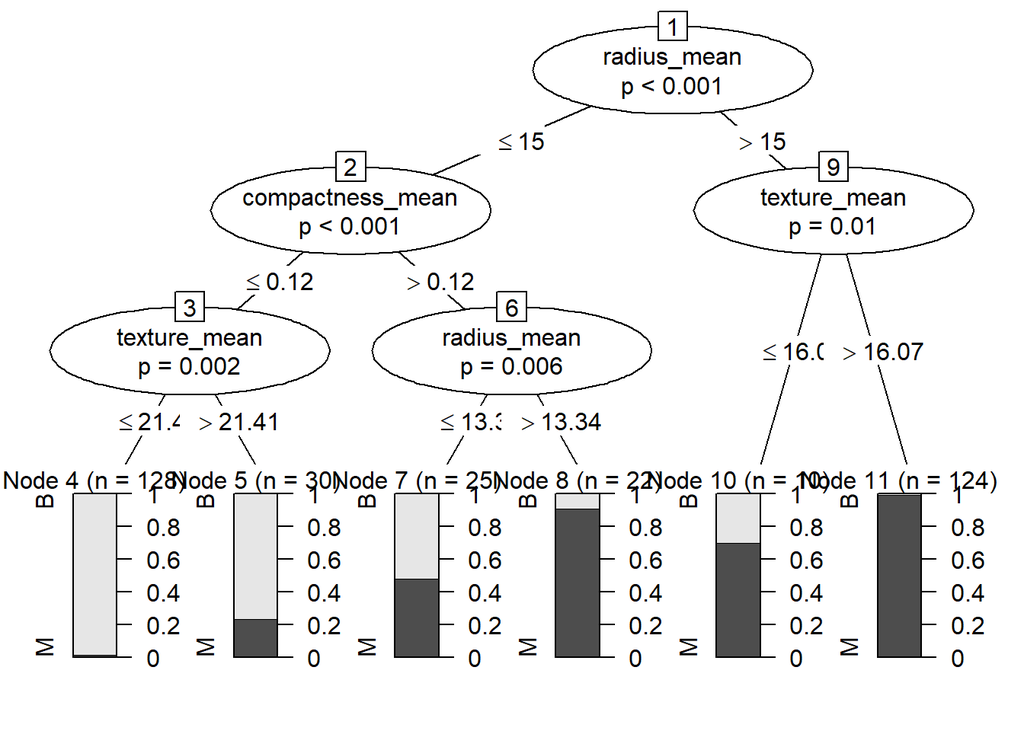

```r
Disease.fit3<-ctree(formula= diagnosis~ radius_mean+texture_mean+smoothness_mean+ compactness_mean,data=split.train1,
                   controls = ctree_control(maxdepth = 3))
plot(Disease.fit3)
```

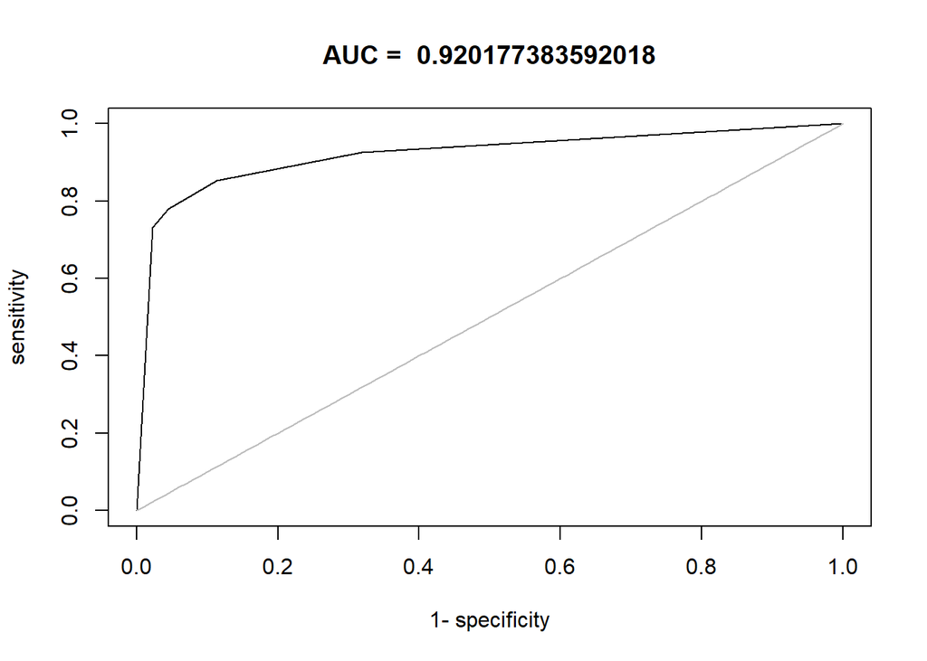

```r
results3r3 = predict(Disease.fit3,
                    newdata=split.test1,
                    type="response")
tree_confmat3<-table(split.test1[,"diagnosis"],results3r3,dnn=c("actual","predicted"))
results3p3 = predict(Disease.fit3, newdata=split.test1,
                    type="prob")
results3p.df3 = t(as.data.frame(results3p3))
roc_result33 = roc(results3p.df3[,2],split.test1$diagnosis)
plot(roc_result33, main=paste("AUC = ", auc(roc_result33), sep=" "))
```